# Capstone Project Milestone Report

ThuyLe

5/7/2021

## Executive Summary

```r
en_blogs = readLines("/Users/thuyle/Documents/Documents_Thuy’sMacBookAir/Data science course/Capstone_project/data/en_US/en_US.blogs.txt")
en_news = readLines("/Users/thuyle/Documents/Documents_Thuy’sMacBookAir/Data science course/Capstone_project/data/en_US/en_US.news.txt")
en_twitter = readLines("/Users/thuyle/Documents/Documents_Thuy’sMacBookAir/Data science course/Capstone_project/data/en_US/en_US.twitter.txt")
```

#### I used quanteda package for natural language process (building corpus, cleaning and tokenizing the corpus as well as building ngram). Some other packages like tidyr, dplyr, data.table are used to clean the data and build the table for ngram.

```r
library(quanteda)
library(tm)
library(tidyr)
library(dplyr)
library(ngram)
library(data.table)
library(stringr)
library(wordcloud)
```

### Sampling the data

```r
samples_blogs <- en_blogs[rbinom(length(en_blogs), 1, 0.3) ==1]
samples_news <- en_news[rbinom(length(en_blogs), 1, 0.3) ==1]
samples_twitter <- en_twitter[rbinom(length(en_blogs), 1, 0.3) ==1]
data <- c(samples_blogs, samples_news, samples_twitter)
```

### Exploratory analysis

#### Tokenize and cleaning the texts with quanteda package:

```r
tokendata <- function(data) {
  data <- tokens(data)
  data <- tokens_tolower(data)
  data <- tokens(data, split_hyphens = TRUE)
  data <- tokens(data, remove_separators = TRUE)
  data <- tokens(data, remove_punct = TRUE)
  data <- tokens(data, remove_url = TRUE)
  data <- tokens(data, remove_symbols = TRUE)
  data <- tokens(data, remove_numbers = TRUE)
  data <- tokens_remove(data, stopwords("en"))
 data <- tokens_select(data, c("[^a-zA-Z]", "([a-zA-Z0-9])\\1\\1+"), selection = "remove", valuetype = "regex")
  return(data)
}
dt <- tokendata(data)
```

### Unigram

#### We shall use tokens_grams function with n = 1 to build unigram. Then building the document feature matrix. The matrix shows the count of each word by line of text (coresponding to each column). Therefore, we have to summarize by column to obtain the total count of each word. Afterward turning document features matrix to a table for further process.

```r
dt <- corpus(data)
dt <- tokendata(data)
ngram <- tokens_ngrams(dt, n=1)
dfm <- dfm(ngram)
dfm <- dfm_trim(dfm, min_termfreq = 10)
dfmS <- colSums(dfm)
unigram <- data.table(word1=names(dfmS), freq=dfmS)
setkey(unigram, word1)
unigram <- arrange(unigram, -freq)
head(unigram)
```

```
##    word1  freq
## 1:  will 94691
## 2:  said 91846
## 3:  just 91643
## 4:   one 89771
## 5:  like 81502
## 6:   can 73962
```

### Bigram and Trigram

#### Simmilarly, we get bigram and trigram, just have to change n to 2 and 3 respectively in tokens_gram function. The difference is to split the 2-word strings to 2 words on 2 columns as well as split 3-word strings to 3 words into 3 columns in the table.

```r
ngram2 <- tokens_ngrams(dt, n=2)
dfm2 <- dfm(ngram2)
dfm2 <- dfm_trim(dfm2, min_termfreq = 20)
dfm2S <- colSums(dfm2)
bigram <- data.table(
  word1 = sapply(strsplit(names(dfm2S), "_", fixed = TRUE), "[[", 1),
  word2 = sapply(strsplit(names(dfm2S), "_", fixed = TRUE), "[[", 2),
  freq = dfm2S
)
setkey(bigram, word1, word2)
bigram <- arrange(bigram, -freq)

discount_value <- 0.75
head(bigram)
```

```
##    word1  word2 freq
## 1: right    now 7581
## 2:   new   york 5956
## 3:  year    old 5881
## 4:  last   year 5648
## 5:  last  night 4810
## 6:  high school 4286
```

```r
trigram <- tokens_ngrams(dt, n=3)
dfm3 <- dfm(trigram)
dfm3S <- colSums(dfm3)
trigram <- data.table(
  word1 = sapply(strsplit(names(dfm3S), "_", fixed = TRUE), "[[", 1),
  word2 = sapply(strsplit(names(dfm3S), "_", fixed = TRUE), "[[", 2),
  word3 = sapply(strsplit(names(dfm3S), "_", fixed = TRUE), "[[", 3),
  freq = dfm3S
)
setkey(trigram, word1, word2, word3)
trigram <- arrange(trigram, -freq)
head(trigram)
```

```
##    word1   word2 word3 freq
## 1:   let      us  know  790
## 2:   new    york  city  746
## 3: happy     new  year  563
## 4: happy mothers   day  525
## 5:   two   years   ago  501
## 6:   new    york times  437
```

### Visualizing the ngram with word cloud

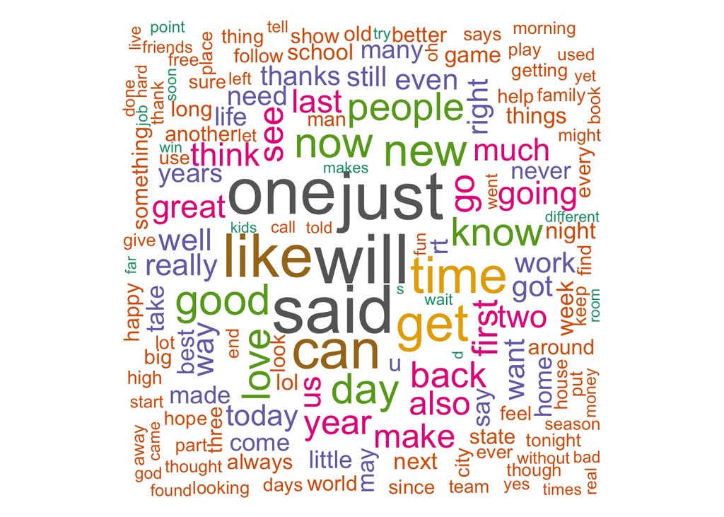

```r
set.seed(1234)
unicloud <-  wordcloud(words = unigram$word1, freq = unigram$freq, min.freq = 1,
            max.words=200, random.order=FALSE, rot.per=0.35,
            colors=brewer.pal(8, "Dark2"))
```

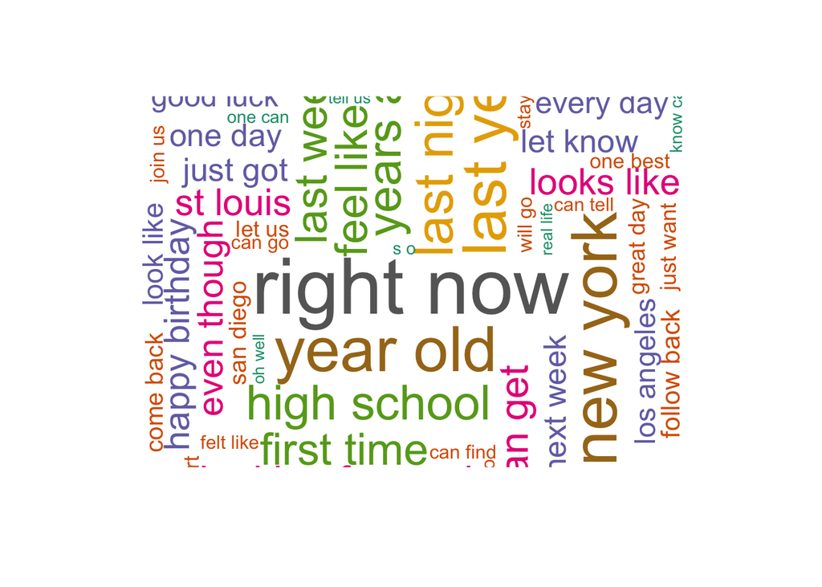

```r
bicloud <-  wordcloud(words = paste(bigram$word1, bigram$word2), freq = bigram$freq, min.freq = 1,
                       max.words=200, random.order=FALSE, rot.per=0.35,
                       colors=brewer.pal(8, "Dark2"))
```

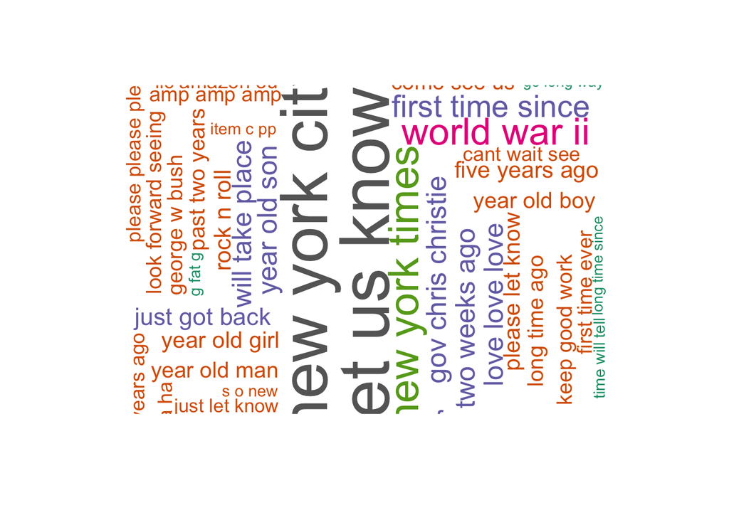

```r
trigram <- wordcloud(words = paste(trigram$word1, trigram$word2, trigram$word3), freq = trigram$freq, min.freq = 1,
                     max.words=200, random.order=FALSE, rot.per=0.35,
                     colors=brewer.pal(8, "Dark2"))
```

## The goal for eventual app and algorithm

#### The next step we shall build the algorithm of prediction model based on Kneser Ney Smoothing. This is a method primarily used to calculate the probability distribution of n-grams in a document based on their histories. The next word is suggested based on not only it’s probability but also the words preceding it.

#### We shall build 3 functions. The first one randomly return one of five words having highest probability. The second one return the word with highest probability to go with one preceding word. The last one return the highest frequent word to appear after two preceding words.Then we build the function to predict the next word when we type a sequence of words. It will take the guess from trigram first. If there is no word found, it will work in bigram, then unigram.